# Football Data Analysis

## 4.b

1. Titles - there were no titles at all to the plots.
2. Overriding lables - the labels on the X-axis are overriding one another.
3. Relevant labels - the xlab and ylab doesn’t have a relevant names. It’s not obvious what the plots are trying to show. for example - the ylab in the second plot have the name “DIV”. we cant understand easily what is the meaning of the plot with this label and what the data-analyst are trying to show.
4. Empty strings - the data frame “cleaned_data” tries to deal with NA’s while in fact there were none, but it didn’t deal with empty strings for clubs or nationalities.
5. Same variable for 2 different plots - the data-analyst set the same variable (g) for two different plots, which is override the former and can lead to mistakes and problems with the program.
6. The thin colored frame of the bins - its really hard to notice and distinguish between the colors with such a thin frames like that. if you choose to color the frame - make it clearly visible.
7. Uneasy to understand the ggplot’s syntax - the use of pipe inside the ggplot make it really long and difficult to understand. we can do it outside the ggplot or take the countries we want with more simple ways like [m:n].

## 4.c

Our corrections to the code :

```r
DIV <- function(category_vec)
{
  t <- table(category_vec)
  p <- t/sum(t)
  return(sum(p^2))
}
#getting rid of blank strings:
cleaned_data = fifa_players %>% select(Nationality,Club) %>% filter(Club!="")%>% filter(Nationality!="")

number_of_nationality_in_club = cleaned_data %>% group_by(Club,Nationality) %>% summarise(count = n()) %>% group_by(Club) %>% summarise(N_nation=n()) %>% arrange(desc(N_nation)) %>% mutate(Club = factor(Club,level = unique(Club)))
```

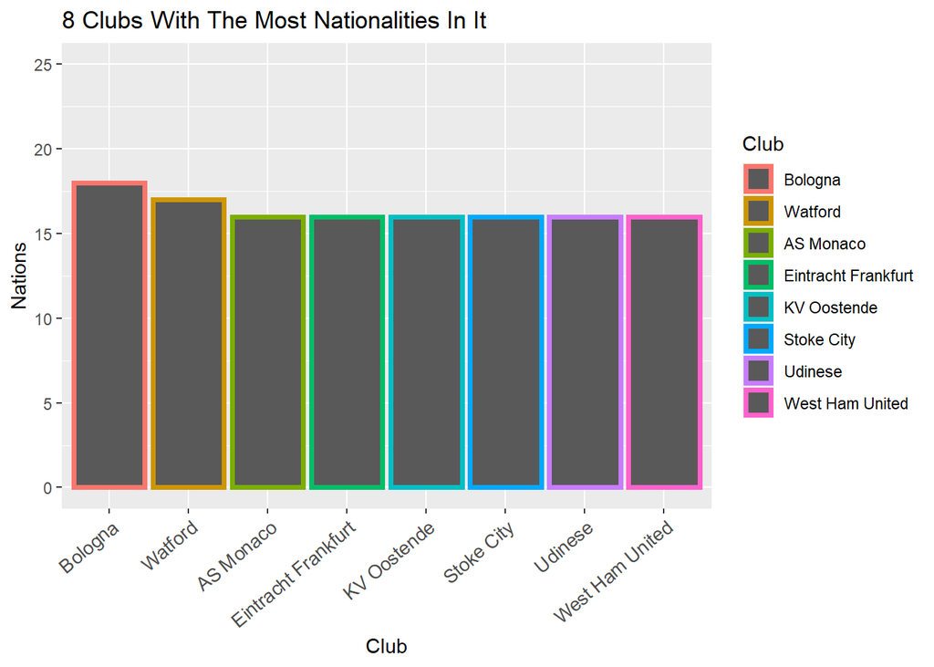

```r
DIV_in_club = cleaned_data %>% group_by(Club) %>% summarise(DIV = DIV(Nationality))%>% arrange(DIV)%>% mutate(Club = factor(Club,level = unique(Club)))

# first plot :
 plot1 = ggplot(data = number_of_nationality_in_club[1:8,], aes(x = Club,y = N_nation,color = Club)) +
  geom_bar(stat="identity", size = 1.35) + ylab("Nations") +ylim(0,25) +
  ggtitle(label = "8 Clubs With The Most Nationalities In It") +
  theme(axis.text.x = element_text(angle = 40, hjust = 1, size = 10))

plot1
```

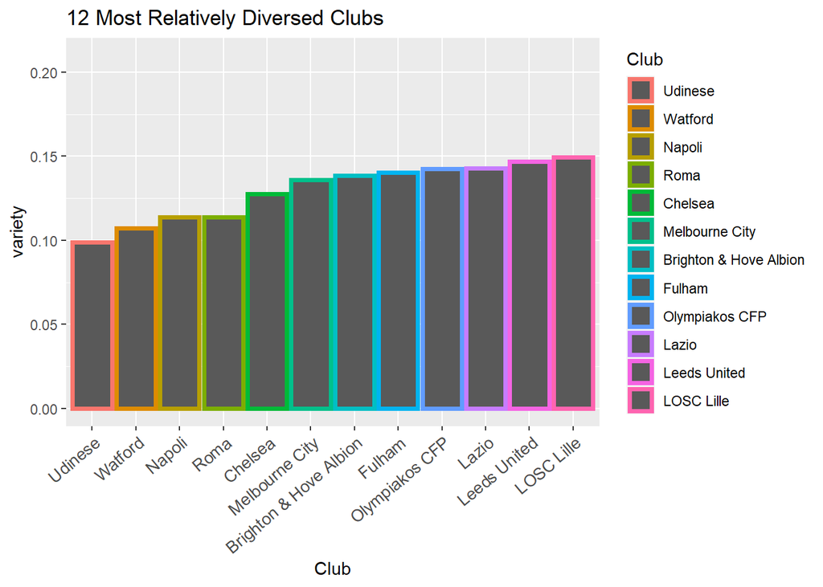

```r
# second plot :
plot2 = ggplot(data = DIV_in_club[1:12,], aes(x = Club,y = DIV, color = Club)) +
  geom_bar(stat = "identity", size = 1.35) +
  ggtitle(label = "12 Most Relatively Diversed Clubs")+ ylim(0, 0.21)+
  labs(y = "variety") +
  theme(axis.text.x = element_text(angle = 40, hjust = 1, size = 10))

plot2
```